# An introduction to optimization on smooth manifolds 2-3章

Author

とり

Published

April 29, 2026

$$\newcommand{\D}{\mathrm{D}}
\newcommand{\E}{\mathcal{E}}
\newcommand{\F}{\mathcal{F}}
\newcommand{\R}{\mathbb{R}}
\newcommand{\M}{\mathcal{M}}
\newcommand{\S}{\mathrm{S}}
\newcommand{\T}{\mathrm{T}}
\newcommand{\X}{\mathfrak{X}}
\newcommand{\SO}{\mathrm{SO}}
\newcommand{\Sym}{\mathrm{Sym}}
\newcommand{\Ret}{\mathrm{R}}
\DeclareMathOperator{\tr}{tr}
\DeclareMathOperator{\Proj}{Proj}
\DeclareMathOperator{\grad}{grad}
\DeclareMathOperator{\rank}{rank}
\DeclareMathOperator{\Im}{im}
\newcommand{\norm}[1]{\|#1\|}
\newcommand{\ang}[1]{\langle{#1}\rangle}$$

# 2 Simple examples

多様体上の最適化問題の例を眺める章．いくつか取り上げて紹介する．

## 2.2 Single extreme eigenvalue or singular value: spheres

対称行列 $A\in\R^{n\times n}$ の最大固有値を求める問題は Rayleigh 商の最大化問題：
$$\lambda_n=\max_{x\in\R^n\setminus\{0\}}\frac{\ang{x,Ax}}{\norm{x}}.$$

Rayleigh 商は尺度変換に不変なので，球面 $\S^{n-1}=\{x\in\R^n\mid \norm{x}=1\}$ 上の最適化問題としても表せる：
$$\max_{x\in\S^{n-1}}\ang{x,Ax}.$$

行列 $M\in\R^{m\times n}$ の最大特異値を求める問題も球面の直積 $\S^{m-1}\times\S^{n-1}$ 上の最適化問題として表せる：
$$\max_{(x,y)\in\S^{m-1}\times\S^{n-1}}\ang{x,My}.$$

## 2.5 Synchronization of rotations: special orthogonal group

$\R^d$ 上の物体の姿勢は，基準となる姿勢を $I_d$ として，特殊直交群
$$\SO(d)\coloneqq\{R\in\R^{d\times d}\mid R^\top R=I_d,\det R=1\}$$

の要素で表せる．

いま，$n$ 個のカメラの姿勢 $R_1,\dots,R_n\in\SO(d)$ に興味があるとする． ただし，$R_1,\dots,R_n$ は未知で，カメラ $j$ から見たカメラ $i$ の相対的な姿勢＋誤差 $H_{ij}\in\SO(d)$ のみがいくつかのペア $(i,j)\in G$ で観測できている．このとき，誤差がなければ $H_{ij}=R_iR_j^\top$ なので，
$$\min_{R_1,\dots,R_n}\sum_{(i,j)\in G}\norm{H_{ij}-R_iR_j^\top}^2=2d|G|-2\sum_{(i,j)\in G}\tr(R_jR_i^\top H_{ij})$$
という最小化問題を解いて $R_1,\dots,R_n$ を推定することが考えられる．

この問題は，行列 Langevin 分布 $L_d(M,\kappa)$ の最尤推定として解釈できる．$L_d(M,\kappa)$ は以下の密度をもつ：
$$p(R\mid M,\kappa)=\frac{1}{Z(\kappa)}\exp(\kappa\tr(M^\top X)),\quad M\in\SO(d),\,\kappa>0.$$

ただし，$Z(\kappa)$ は正規化定数．$H_{ij}\sim L_d(R_iR_j^\top,\kappa)$ とすると，対数尤度は
$$\kappa\sum_{(i,j)\in G}\tr(R_jR_i^\top H_{ij})-|G|\log Z(\kappa)$$

となる．

# 3 Embedded geometry: first order

滑らかな関数 $f\colon\M\to\R$ を最小化する $x\in \M$ を探したい． ここで，$\M\subset\R^d$ は $\R^d$ に埋め込まれた部分多様体（後で定義）．例えば，球面 $\S^{d-1}\coloneqq\{x\in\R^d\mid \norm{x}=1\}$ がある．

$f\colon\R^d\to\R$ に対する勾配降下法は，$x_{k+1}\coloneqq x_{k}-\alpha_k\grad f(x_k)$ によって解を更新する．$\alpha_k>0$ はステップサイズ．4章で勾配降下法を $f\colon\M\to\R$ に拡張する．この章では，前準備として以下の疑問を解消する：

- $f\colon\M\to\R$ の勾配 $\grad$ はどう定義する？（→ Riemann 勾配）
- $x_{k+1}$ が $\M$ からはみ出した場合はどうする？（→ レトラクション）

## 3.2 Embeded submanifolds of a linear space

- $\E,\F$ は有限次元実内積空間（$\R^d$ や $\R^{n\times p}$ など）．
- 開集合 $U\subset\E,V\subset\F$ の間の滑らかな写像 $F\colon U\to V$ の $x\in U$ での微分 $\D F(x)\colon\E\to\F$ とは．
  $$\D F(x)[u]\coloneqq\left.\frac{\mathrm{d}}{\mathrm{d}t}F(x+tu)\right|_{t=0}$$
  で定まる線形写像．
- 滑らかな関数 $f\colon \E\to\R$ の勾配 $\grad f\colon\E\to\E$ とは，
  $$\ang{\grad f(x),v}=\D f(x)[v],\quad \forall x,v\in\E$$
  を満たす（唯一の）写像．

**Definition 1 (Definition 3.10 Embedded submanifold)** $\dim\E=d$ とする．空でない $\M\subset\E$ が次元 $n(\leq d)$ の（滑らかな）埋め込まれた部分多様体であるとは，

$n=d$ の場合：$\M$ が $\E$ の開集合（開部分多様体）．

$n<d$ の場合：各点 $x\in\M$ で $x$ のある近傍 $U$ 上の滑らかな写像 $h\colon U\to\R^{d-n}$ が存在して，

1. $\M\cap U=h^{-1}(\{0\})$.
2. $\rank \D h(x)=d-n$.

が成り立つこと．

- $n$ を $\M$ の次元という．
- $\M$ が線形部分空間なら，$\M$ を線形多様体という．
- $h$ を（ $x$ における）局所定義関数 (local defining function) という．

Definition 1 の1つ目の仮定は $\M$ は局所的には $h=0$ を満たす点の集合と見なせるということ．また，$h$ の Taylor 展開
$$h(x+tv) = h(x) + t\D h(x)[v] + O(t^2)$$

から，$\ker\D h(x)$ は $x\in\M$ の周りでの $\M$ の線形近似と思える．2つ目の仮定は $\M$ を線形近似したときの次元が常に一定であるということ．

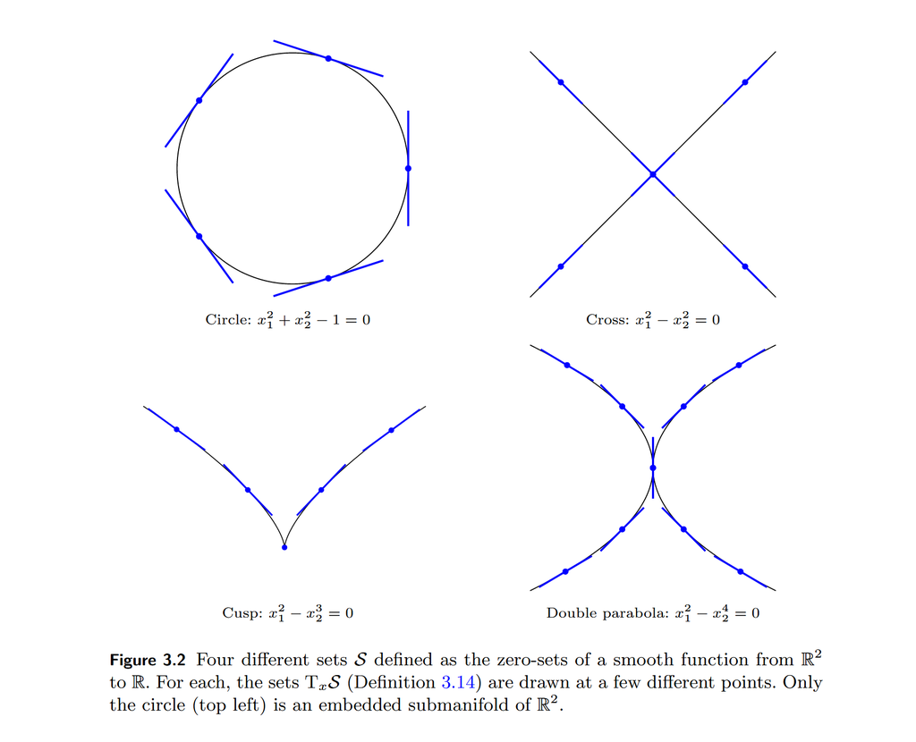

球面は $h(x)\coloneqq\norm{x}^2-1$ によって，部分多様体になるが，他の例はならない．

**Definition 2 (Definition 3.11 微分同相写像)** 滑らかな写像 $F\colon U\to V$ が微分同相であるとは，$F$ が全単射で，$F^{-1}$ も滑らかであること．

**Theorem 1 (Theorem 3.12)** $\dim\E=d$ とする．$\M\subset\E$ が次元 $n$ の（滑らかな）埋め込まれた部分多様体であることは， 各点 $x\in\M$ で $x$ のある近傍 $U$ から $\R^d$ のある開集合 $V$ への微分同相写像 $F\colon U\to V$が存在して，$F(\M\cap U)=\{y\in\R^d\mid y_{n+1}=\cdots=y_{d}=0\}\cap V$ となることと同値．

Theorem 1 の証明には次の逆関数定理を用いる．

**Theorem 2 (Theorem 3.13 逆関数定理)** $\dim\E=\dim\F$ とする．$U\subset\E,V\subset\F$ は開集合で，$F\colon U\to V$ は滑らかとする．ある $x\in U$ で，$\D F(x)$ が正則ならば，$x$ の近傍 $U'\subset U$ と $F(x)$ の近傍 $V'\subset V$ が存在して，$F|_{U'}\colon U'\to V'$ は微分同相．

*Proof* (Theorem 1 の証明). $n=d$ の場合は $\E\simeq\R^d$ の同一視によって，$U=V=\M,F(x)=x$ とすればよい． $n<d$ の場合を考える．

$(\Rightarrow)$: 各点 $x$ で局所定義関数 $h\colon U\to\R^{d-n}$ が存在する． まず，$\rank\D h(x)=d-n$ なので，基底をうまく選んで，$A\in\R^{(d-n)\times n}$ と正則な $B\in\R^{(d-n)\times(d-n)}$ を用いて，$\D h(x)=\begin{bmatrix}A&B\end{bmatrix}\in\R^{(d-n)\times d}$ と表現行列で表せる．この基底の下で，
$$F(y)\coloneqq (y_{1},\dots,y_{n},h_{1}(y),\dots,h_{d-n}(y))^\top$$
とすると，$F$ は滑らかで，
$$\D F(x)=\begin{bmatrix}I_{n}&O\\A&B\end{bmatrix}$$

は正則．逆関数定理より $F$ は所望のもの．

$(\Leftarrow)$: $d-n$ 個の座標関数が消えるような微分同相写像 $F$ が各点 $x$ の近傍上で取れるので， $h\colon U\to\R^{d-n},x\mapsto (F_{n+1}(x),\dots,F_{d}(x))^\top$ としたものが所望のもの．

**Definition 3 (Definition 3.14)** $\M\subset\E$ に対して，
$$\T_{x}\M\coloneqq\{c'(0)\mid\text{$c\colon I\to\M$ は $c(0)=x$ で滑らか, $I$ は $0$ を含む開区間} \}.$$

**Theorem 3 (Theorem 3.15)** $\M\subset\E$ を埋め込まれた部分多様体とする．$x\in\M$ に対して，

- $\M$ が開部分多様体なら，$\T_{x}\M=\E$.
- そうでないなら，$\T_{x}\M=\ker\D h(x)$. ただし，$h$ は $x$ における局所定義関数．

*Proof*. $\M$ が開部分多様体なら，$c(t)\coloneqq x+tv$ が任意の $v\in\E$ と十分小さい $t$ に対してとれるので明らか．そうでない場合を示す．

$d=\dim\E,n=\dim\M$ とする．証明の方針は次の通り．まず，$T_x\M\subset\ker\D h(x)$ を示す． 次に，$\dim\T_x\M\geq n$ を示す．そうすると，$\rank\D h(x)=d-n$ より，$T_x\M=\ker\D h(x)$ が従う．

$\T_x\M\subset \ker\D h(x)$ であること：

$v\in\T_x\M$ に対して，$c(0)=x,c'(0)=v$ を満たす曲線 $c$ が取れる．十分小さい $t$ については，$h(c(t))=0$ である．したがって，
$$0=\frac{\mathrm{d}}{\mathrm{d}t}h(c(t))=\D h(c(t))[c'(t)].$$

$t=0$ を代入して，$v\in\ker\D h(x)$ を得る．

$\dim\T_x\M\geq n$ であること：

Theorem 1 の微分同相写像 $F$ をとる．任意の $u\in\R^{n}$ について，
$$\gamma(t)\coloneqq F(x)+t\begin{bmatrix}u\\0\end{bmatrix}$$

とすると，十分小さい $t$ については $\gamma(t)\in V$ で $V$ 上の滑らかな曲線になっている． よって，$\M$ 上の滑らかな曲線を $c(t)\coloneqq F^{-1}(\gamma(t))$ で定めることができる．$c(0)=x$ である．また，
$$c'(0)=\D F^{-1}(\gamma(t))[\gamma'(t)]|_{t=0}=\D F^{-1}(F(x))\begin{bmatrix}u\\0\end{bmatrix}=(\D F(x))^{-1}\begin{bmatrix}u\\0\end{bmatrix}$$

である．$u$ は任意だったので，$\dim\T_{x}\M\geq n$ である．

**Definition 4 (Definition 3.16 接空間，接ベクトル)** 部分多様体 $\M\subset\E$ の $x\in\M$ における接空間とは $\T_x\M$ のこと．$v\in\T_x\M$ を接ベクトルという．

**Example 1 (Example 3.17)** $\R^d$ は線形多様体で，$\T_{x}\R^d=\R^d$．

$A\in\R^{k\times d},b\in\R^d,\rank A=k$ について，アフィン部分空間 $\M\coloneqq\{x\in\R^d\mid Ax=b\}$ は $d-k$ 次元の部分多様体．

**Example 2 (Example 3.18)** $\S^{d-1}\coloneqq\{x\in\R^d\mid \norm{x}=1\}$ は局所定義関数 $h(x)=\norm{x}^2-1$ に関する部分多様体．$\T_x\S^{d-1}=\ker\D h(x)=\{v\in\R^d\mid \ang{x,v}=0\}$.

**Example 3 (Example 3.19)** 階数1の2次実対称行列全体
$$\Sym(2)_1\coloneqq\left\{X=\begin{bmatrix}x_1&x_2\\x_2&x_3\end{bmatrix}\,\middle|\, \rank X=1\right\}$$

は $\Sym(2)$ の1次元部分多様体で，

$$\T_X\Sym(2)_1=\left\{\dot{X}=\begin{bmatrix}\dot{x}_1&\dot{x}_2\\\dot{x}_2&\dot{x}_3\end{bmatrix}\,\middle|\,\dot{x}_1x_3+x_1\dot{x}_3-2x_2\dot{x}_2=0\right\}.$$

*Proof*. $X\in\Sym(2)_1$ の近傍として $U=\Sym(2)\setminus\{0\}$ をとって，局所定義関数を $h\colon U\to\R,X\mapsto\det X$ で定める．

このとき，$\Sym(2)_1\cap U=h^{-1}(\{0\})$ で，
$$\begin{align*}
\D h(X)[\dot{X}]
&=\left.\frac{\mathrm{d}}{\mathrm{d}t}\big\{(x_1+t\dot{x}_1)(x_3+t\dot{x}_3)-(x_2+t\dot{x}_2)^2\big\}\right|_{t=0}\\
&=x_1\dot{x}_3+\dot{x}_1x_3-2x_2\dot{x}_2\\
&=\begin{bmatrix}x_3&-2x_2&x_1\end{bmatrix}\begin{bmatrix}\dot{x}_1\\\dot{x}_2\\\dot{x}_3\end{bmatrix}
\end{align*}$$

より，$\rank\D h(X)=1$.

- $\Sym(2)_1$ は $\Sym(2)$ 上，開でも閉でもないし，連結でもない．

**Proposition 1 (Proposition 3.20 埋め込まれた部分多様体の直積)** $\M,\M'$ はそれぞれ，$\E,\E'$ に埋め込まれた部分多様体とする． $\M\times \M'$ は $\E\times \E'$ に埋め込まれた部分多様体で，$\dim(\M\times\M')=\dim\M+\dim\M'$． また，
$$\T_{(x,x')}(\M\times\M')=\T_x\M\times\T_{x'}\M'.$$

*Proof*. 局所定義関数として，それぞれの局所定義関数の組 $(h,h')$ が取れる．あとは，$\R^{\dim\E-\dim\M}\times\R^{\dim\E'-\dim\M'}$ を $\R^{(\dim\E+\dim\E')-(\dim\M+\dim\M')}$ と同一視すればよい．

- $\M$ には，$\E$ の相対位相が入る（Definition 3.21, Definition 3.22）．
- $\M$ の近傍とは，$\M$ を含む $\E$ の開集合のこと．

**Proposition 2 (Proposition 3.23)** $\M$ の開集合 $\mathcal{U}$ もまた，$\E$ の部分多様体で，$x\in\mathcal{U}$ に対して，$T_{x}\mathcal{U}=T_{x}\M$.

*Proof*. $x\in\mathcal{U}$ の $\M$ における局所定義関数 $h$ の定義域を十分小さく取り直せば $\mathcal{U}$ における局所定義関数がつくれる．

## 3.3 Smooth maps on embedded submanifolds

**Definition 5 (Definition 3.30 滑らかな写像)** $\M,\M'$ はそれぞれ，$\E,\E'$ の埋め込まれた部分多様体とする． $F\colon\M\to\M'$ が $x\in\M$ で滑らかとは，$x$ のある近傍 $U\subset\E$ 上の滑らかな写像 $\overline{F}\colon U\to\E'$ が存在して，$\M\cap U$ 上 $F=\overline{F}$ となること．

- $F$ が滑らかとは，各点 $x\in\M$ で滑らかなこと．
- $\overline{F}$ を $x$ における $F$ の（滑らかな）拡張という．

$F$ の拡張 $\overline{F}$ は大域的にとることもできる：

**Proposition 3 (Proposition 3.31）)** $\M,\M'$ はそれぞれ，$\E,\E'$ の埋め込まれた部分多様体とする． $F\colon\M\to\M'$ が滑らかであることは，$\M$ のある近傍から $\E'$ への滑らかな写像 $\overline{F}$ で，$F=\overline{F}|_\M$ を満たすものが存在することと同値．

**Definition 6 (Definition 3.32 スカラー場)** 多様体 $\M$ の（滑らかな）スカラー場とは，$\M$ 上の（滑らかな）関数のこと．滑らかなスカラー場全体を $\mathfrak{F}(\M)$ で表す．

## 3.4 The differential of a smooth map

**Definition 7 (Definition 3.34 滑らかな写像の微分)** 埋め込まれた多様体 $\M,\M'$ の間の滑らかな写像 $F\colon\M\to\M'$ の $x\in\M$ における微分 $\D F(x)\colon\T_{x}\M\to\T_{F(x)}\M'$ とは，以下で定まる線形写像のこと：
$$\D F(x)[v]\coloneqq\left.\frac{\mathrm{d}}{\mathrm{d}t}F(c(t))\right|_{t=0}=(F\circ c)'(0).$$
ただし，$c$ は $c(0)=x,c'(0)=v$ を満たす $\M$ 上の滑らかな曲線．

- 連鎖律から，$F\colon\M\to\M'$ と $F'\colon\M'\to\M''$ に対して，
  $$\D(F'\circ F)(x)[v]=\D F'(F(x))[\D F(x)[v]].$$

**Proposition 4 (Proposition 3.35)** $F\colon\M\to\M'$ は滑らかで，$\overline{F}$ は $x\in\M$ における拡張とする．このとき， $\D F(x)=\D \overline{F}(x)|_{\T_{x}\M}$.

*Proof*. $x$ のある近傍 $U$ が存在して $\M\cap U$ 上，$F=\overline{F}$ である．したがって，
$$\D F(x)[v]
=\left.\frac{\mathrm{d}}{\mathrm{d}t}F(c(t))\right|_{t=0}
=\left.\frac{\mathrm{d}}{\mathrm{d}t}\overline{F}(c(t))\right|_{t=0}
=\D\overline{F}(c(0))[c'(0)]
=\D\overline{F}(x)[v].$$

**Example 4 (Example 3.36)** $A\in\R^{d\times d}$ は対称行列とする．$f\colon\S^{d-1}\to\R,x\mapsto \ang{x,Ax}$ は滑らかな拡張 $\overline{f}\colon\R^{d}\to\R,x\mapsto\ang{x,Ax}$ をもつので，
$$\D f(x)[v]=\D\overline{f}(x)[v]=2\ang{v,Ax}.$$

## 3.5 Vector fields and the tangent bundle

- $x\in\M$ をある $v\in\T_{x}\M$ に対応させる写像 $V$ のことを $\M$ 上のベクトル場という．

**Definition 8 (Definition 3.42 ベクトル束)** 多様体 $\M$ のベクトル束 $\T\M$ とは，接空間の非交差和のこと：
$$\T\M\coloneqq\{(x,v)\mid x\in\M,v\in\T_x\M\}.$$

- $\T(\M\times \M')=\T\M\times \T\M'$ である．

**Theorem 4 (Theorem 3.43)** $\E$ の部分多様体 $\M$ のベクトル束 $\T\M$ は $\E\times \E$ の部分多様体で，$\dim\T\M=2\dim\M$.

証明のために補題を1つ準備する．

**Lemma 1 (Lemma 3.74)** $x\in\E$ のある近傍 $U$ 上の滑らかな写像 $h\colon U\to\R^k$ は $\rank\D h(x)=k$ を満たすとする．このとき，$x$ のある近傍 $U'\subset U$ が存在して，任意の $x'\in U$ に対して，$\rank\D h(x')=k$.

*Proof*.
$$U'\coloneqq\{x'\in U\mid \rank\D h(x')=k\}$$
が開集合であることを示せば十分．$\E$ の基底を固定して，$\D h(x')\in\R^{k\times d}$ とみなす．$g\colon U\to\R,x'\mapsto \det(\D h(x')\D h(x')^\top)$ とすると，$U'=U\setminus g^{-1}(\{0\})$ である．$g$ は連続なので，$U'$ は開集合．

*Proof* (Theorem 4 の証明). $\M$ が開部分多様体の場合は明らか．実際，$\T_x\M=\E$ で，$\T\M=\M\times \E$ は $\E\times \E$ の開集合．そうでない場合を示す．

$d=\dim\E,n=\dim\M$ とする．$h\colon U\to\R^{d-n}$ をある $x\in\M$ の局所定義関数とする．

$H\colon U\times\E\to\R^{2(d-n)}$ を
$$H(x,v)\coloneqq\begin{bmatrix}h(x)\\\D h(x)[v]\end{bmatrix}$$

で定める．これが，局所定義関数になっていることを示す．

$\T\M\cap(U\times\E)=H^{-1}(\{0\})$ であること：

Lemma 1 より，$U$ 上 $\rank\D h(x)=k$ となるように $U$ をとれる． このとき $h$ は任意の $x\in\M\cap U$ の局所定義関数にもなっている．したがって， $(x,v)\in U\times \E$ に対して，
$$(x,v)\in\T\M\iff h(x)=0,\enspace \D h(x)[v]=0$$
である．したがって，$\T\M\cap(U\times\E)=H^{-1}(\{0\})$ が得られた．

$\rank\D H(x,v)=2(d-n)$ であること：
$$\begin{align*}
\D H(x,v)[\dot{x},\dot{v}]
&=\left.\frac{\mathrm{d}}{\mathrm{d}t}\begin{bmatrix}h(x+t\dot{x})\\\D h(x+t\dot{x})[v+t\dot{v}]\end{bmatrix}\right|_{t=0}\\
&=\left.\frac{\mathrm{d}}{\mathrm{d}t}\begin{bmatrix}h(x+t\dot{x})\\\D h(x+t\dot{x})[v]+t\D h(x+t\dot{x})[\dot{v}]\end{bmatrix}\right|_{t=0}\\
&=\begin{bmatrix}\D h(x)[\dot{x}]\\\mathcal{L}(x,v)[\dot{x}]+\D h(x)[\dot{v}]\end{bmatrix}\\
&=\begin{bmatrix}\D h(x)&0\\\mathcal{L}(x,v)&\D h(x)\end{bmatrix}\begin{bmatrix}\dot{x}\\\dot{v}\end{bmatrix}\\
\end{align*}$$

ただし，$\mathcal{L}(x,v)[\dot{x}]\coloneqq\frac{\mathrm{d}}{\mathrm{d}t}\D h(x+t\dot{x})[v]|_{t=0}$ とした．ブロック三角行列の性質から，$\rank\D H(x,v)\geq\rank\D h+\rank\D h=2(d-n)$ が成り立つ（Lemma 2）． また，$H$ は $\R^{2(d-n)}$ への写像なので，$\rank\D H(x,v)\leq 2(d-n)$．よって，$\rank\D H(x,v)=2(d-n)$．

**Definition 9 (Definition 3.44 ベクトル場)** 多様体 $\M$ 上の（滑らかな）ベクトル場とは，（滑らかな）写像 $V\colon\M\to\T\M$ で，$V(x)\in\T_{x}\M$ を満たすもののこと．滑らかなベクトル場全体を $\X(\M)$ で表す．

**Proposition 5 (Proposition 3.45)** 埋め込まれた部分多様体 $\M$ 上のベクトル場 $V$ が滑らかであることは，$\M$ のある近傍上の滑らかなベクトル場 $\overline{{V}}$ で $\overline{V}|_\M$ を満たすものが存在することと同値．

*Proof*. $(\Leftarrow)$ は明らかなので，$(\Rightarrow)$ を示す．

Proposition 3 より，$\M$ のある近傍 $U$ から $\E\times\E$ の滑らかな写像 $W$ で，$V=W|_\M$ を満たすものが存在する．$W(x)=(W_1(x),W_2(x))$ とすると，$W_1,W_2$ はどちらも滑らか．しかし，$U$ 上 $W_1(x)=x$ とは限らないので，$W$ は開部分多様体 $U$ 上のベクトル場とは限らない．$\overline{V}(x)\coloneqq(x,W_2(x))$ とすると，これは，$U$ 上のベクトル場で，$V=\overline{V}|_\M$ である．

## 3.6 Moving on a manifold: retractions

**Definition 10 (Definition 3.47 レトラクション)** 多様体 $\M$ 上のレトラクションとは，滑らかな写像 $\Ret\colon\T\M\to\M,(x,v)\mapsto\Ret_x(v)$ で，曲線 $c(t)\coloneqq\Ret_x(tv)$ が $c(0)=x,c'(0)=v$ を満たすもののこと．

- レトラクションが与えられると，各点 $x\in\M$ で速度が $v\in\T_x\M$ であるような曲線が定まる．
- 多様体上の勾配降下法では，レトラクションが定める曲線に沿って点を更新する．
- 線形多様体のレトラクションの例：$\Ret_x(v)\coloneqq x+v$ (Example 3.48)．
- 球面 $S^{d-1}$ のレトラクションの例 (Example 3.49)：
  - $\Ret_x(v)\coloneqq (x+v)/\norm{x+v}$ （射影して球面に戻す）
  - $\Ret_x(v)\coloneqq\cos(\norm{v})x+\sin(\norm{v})v/\norm{v}$ （$v$ が定める大円に沿って動く）
- 行列 Lie 群のレトラクションは $\Ret_X(V)\coloneqq X\exp(X^{-1} V)$ で構成できる（が計算コストが高いらしい）．これがレトラクションの定義を満たすことは行列指数関数の微分が恒等写像になることからわかる．
  - $\SO(d)$ などでは，$\Ret_X(V)\coloneqq\mathrm{QR}(X+V)_Q$ とできる（らしい）（行列指数関数よりは高速らしい）．$X+tV=Q(t)R(t)$ とすると，$V=\dot{Q}(0)R(0)+Q(0)\dot{R}(0)=\dot{Q}(0)+Q\dot{R}(0)$ となって，接空間の構造から，$\dot{R}(0)=0$ が示される．

**Proposition 6** $\Ret\colon\T\M\to\M$ について，以下は同値

1. $\Ret$ はレトラクション．
2. $\Ret_x(0)=x,\D\Ret_x(0)[v]=v$ （曲線を用いない特徴づけ）.

*Proof*. $c(0)=\Ret_x(0)$ と $c'(0)=\D\Ret_x(0)[v]$ からわかる．

## 3.7 Riemannian manifolds and submanifolds

**Definition 11 (Definition 3.53 Riemann 多様体)** 多様体 $\M$ が Riemann 多様体であるとは，各点 $x\in\M$ の接空間 $\T_x\M$ で内積 $\ang{\,\cdot\,,\,\cdot\,}_x$ が定まっていて，内積が以下を満たすこと：

任意の $V,W\in\X(\M)$ に対して，$x\mapsto\ang{V(x),W(x)}$ が滑らか．

- $\ang{\,\cdot\,,\,\cdot\,}_x$ を Riemann 計量という．

**Proposition 7 (Proposition 3.54 誘導計量)** $\M$ は内積空間 $\E$ に埋め込まれた部分多様体とする．$x\in\M$ に対して，$\ang{u,v}_x\coloneqq\ang{u,v},\enspace u,v\in\T_x\M$ で定めると，$\M$ は Riemann 多様体．

- このような $\M$ を $\E$ の Riemann 部分多様体という (Definition 3.55)．
- $\S^{d-1}$ は $\R^d$ の Riemann 部分多様体で，Riemann 計量は，$\ang{u,v}_x=u^\top v$ (Example 3.56).
- Riemann 多様体 $\M,\M'$ の直積 $\M\times\M'$ は，Riemann 計量 $\ang{(u,u'),(v,v')}_{(x,x')}\coloneqq\ang{u,v}_{x}^\M+\ang{u',v'}_{x'}^{\M'}$ に関して Riemann 多様体になる (Example 3.57)．

## 3.8 Riemannian gradients

**Definition 12 (Definition 3.58 Riemann 勾配)** $\M$ は Riemann 多様体，$f\colon\M\to\R$ は滑らかとする．$f$ の Riemann 勾配 $\grad f$ とは，以下を満たすベクトル場のこと：
$$\D f(x)[v]=\ang{v,\grad f(x)}_x,\quad \forall (x,v)\in\T\M.$$

**Proposition 8** Riemann 勾配は存在すれば一意．

*Proof*. $\M$ 上のベクトル場 $U,V$ が Riemann 勾配の定義を満たすとする．$U=V$ を示す．
$$\D f(x)[v] = \ang{v,U(x)}_x=\ang{v,V(x)}_x,\quad \forall (x,v)\in\T\M$$

より，任意の $x\in\M$ に対して，$\ang{v,U(x)-V(x)}_x=0,\enspace\forall v\in\T_x\M$ が成り立っている．これは，$U(x)=V(x)$ を意味する．よって，$U=V$ である．

**Proposition 9 (Proposition 3.59)** $\M$ は Riemann 多様体，$f\colon\M\to\R$ は滑らかとする． $\Ret$ を $\M$ 上のレトラクションとすると，
$$\grad f(x) = \grad(f\circ\Ret_x)(0),\quad\forall x\in\M.$$

*Proof*. 微分の連鎖律から，任意の $(x,v)\in\T\M$ に対して，
$$\D(f\circ\Ret_x)(0)[v]=\D f(\Ret_x(0))[\D\Ret_x(0)[v]]=\D f(x)[v]=\ang{v,\grad f(x)}_x.$$

**Proposition 10** $\M$ を $\E$ の Riemann 部分多様体とする．$f\colon\M\to\R$ は滑らかとする．$\overline{f}$ を $f$ の $\M$ のある近傍における拡張とすると，
$$\ang{v,\grad f(x)}_x=\ang{v,\grad\overline{f}(x)}_x,\quad\forall (x,v)\in\T\M.$$

*Proof*. Proposition 4 より，$\D f(x)=\D\overline{f}(x)|_{\T_x\M}$ なので明らか．

$\M$ を $\E$ の Riemann 部分多様体とする．$\T_x\M\subset\E$ なので，
$$\grad\overline{f}(x)=\grad\overline{f}(x)_{\|} + \grad\overline{f}(x)_{\perp},\quad\grad\overline{f}(x)_{\|}\in\T_x\M,\,\grad\overline{f}(x)_\perp\in(\T_x\M)^\perp$$

と（$\E$ の内積に関して）直交分解できる．

**Proposition 11**
$$\grad f(x)=\grad\overline{f}(x)_{\|},\quad \forall x\in\M.$$

*Proof*. 任意の $(x,v)\in\T\M$ に対して，
$$\ang{v,\grad f(x)}_x=\ang{v,\grad\overline{f}(x)}_x
=\ang{v,\grad\overline{f}(x)_{\|}+\grad\overline{f}(x)_{\perp}}_x
=\ang{v,\grad\overline{f}(x)_{\|}}_x$$

が成り立つので，$\grad f(x)=\grad\overline{f}(x)_{\|},\quad \forall x\in\M.$

**Definition 13 (Definition 3.60 直交射影)** $\M$ を $\E$ の Riemann 部分多様体とする．$\T_x\M$ への直交射影 $\Proj_x\colon\E\to\E$ とは以下を満たす線形写像のこと：

1. $\Im(\Proj_x)=\T_x\M$.
2. $\Proj_x\circ\Proj_x=\Proj_x$.
3. $\ang{u-\Proj_x(u),v}=0,\quad \forall v\in\T_x\M, \forall u\in\E.$

**Proposition 12 (Proposition 3.61)** $\M$ を $\E$ の Riemann 部分多様体とする．$f\colon\M\to\R$ は滑らかとする．$\overline{f}$ を $f$ の $\M$ のある近傍における拡張とすると，
$$\grad f(x)=\Proj_x(\grad\overline{f}(x)),\quad \forall x\in\M.$$

*Proof*. Proposition 11 の $\grad\overline{f}(x)$ は $\Proj_x(\grad\overline{f}(x))$

- $\M$ が $\E$ の開部分多様体なら，$\T_x\M=\E$ なので，$\Proj_x$ は恒等写像．
- $\S^{d-1}$ の直交射影は，$\Proj_x(u)=u-(x^\top u)x=(I_d-xx^\top)u$ (Example 3.62).
- $f(x)=x^\top Ax,\enspace A\in\Sym(d)$ の Riemann 勾配は，
  $$\grad f(x)=(I_d-xx^\top)(2Ax)=2(Ax-(x^\top Ax)x).$$

**Proposition 13 (Proposition 3.63)** $\Proj_x$ は自己随伴：
$$\ang{u,\Proj_x(v)}=\ang{\Proj_x(u),v},\quad\forall u,v\in\E.$$

*Proof*.
$$\begin{align*}
0&=\ang{u-\Proj_x(u),\Proj_x(v)}\\
&=\ang{u,\Proj_x(v)}-\ang{\Proj_x(u),v-(v-\Proj_x(v))}\\
&=\ang{u,\Proj_x(v)}-\ang{\Proj_x(u),v}+\cancel{\Proj_x(u),v-\Proj_x(v)}.
\end{align*}$$

## 3.9 Local frames

**Definition 14 (Definition 3.68 局所枠)** $n$ 次元多様体 $\M$ の点 $x\in\M$ の周りの局所枠とは，$x$ のある近傍 $U$ 上の滑らかなベクトル場の組 $W_1,\dots,W_n$ で，$y\in U$ に対して，$W_1(y),\dots,W_n(y)$ が $\T_y\M$ の基底になるようなもののこと．

**Proposition 14 (Proposition 3.69)** $\M$ は $\E$ に埋め込まれた部分多様体とする．このとき，$x\in\M$ の周りの局所枠が存在する．

*Proof*. $\dim\E=d,\dim\M=n$ とする．Theorem 1 より，$x\in\M$ のある近傍 $U$ から，$\R^d$ のある開集合 $V$ への微分同相写像 $F\colon U\to V$ で，
$$F(\M\cap U)=\{y\in\R^d\mid y_{n+1}=\cdots=y_d=0\}\cap V$$
を満たすものがとれる．$e_1,\dots,e_d$ を $\R^d$ の標準基底として，
$$W_i(y)\coloneqq\left(t\mapsto F^{-1}(F(y)+te_i)\right)'(0)$$

が局所枠の定義を満たすことを確かめる．

**Tip 1**

$t\mapsto F(y)+te_i$ は $F(\M\cap U)$ 上の曲線で，それを $F^{-1}$ で引き戻して，$\M\cap U$ 上の曲線をつくっている．

$$W_i(y)=\D F^{-1}(F(y))[e_i]=(\D F(y))^{-1}[e_i]$$

$\D F(y)$ は可逆なので，線形独立な系 $e_1,\dots,e_n$ は線形独立な系 $W_1(y),\dots,W_n(y)$ にうつる．

- 枠は大域的にとることもできる．例えば，$\S^1$ など．$\S^2$ では無理（らしい）．

**Proposition 15 (Proposition 3.70)** $\E$ に埋め込まれた Riemann 多様体 $\M$ 上の滑らかな関数 $f$ の勾配ベクトル場 $\grad f$ は滑らか．

*Proof*. $x\in\M$ の近傍 $U$ で定義された局所枠 $W_1,\dots,W_n$ をとる．
$$\grad f(y)=g_1(y)W_1(y)+\cdots+g_n(y)W_n(y),\quad y\in U$$
と，基底展開できる．$g_i$ が滑らかであることを示せばよい．上の式より，
$$\begin{align*}
&\begin{bmatrix}
\ang{W_1(y),W_1(y)}_y&\cdots&\ang{W_n(y),W_1(y)}_y\\
\vdots&\ddots&\vdots\\
\ang{W_n(y),W_1(y)}_y&\cdots&\ang{W_n(y),W_n(y)}_y
\end{bmatrix}
\begin{bmatrix}g_1(y)\\\vdots\\g_n(y)\end{bmatrix}\\
&=
\begin{bmatrix}
\ang{\grad f(y),W_1(y)}_y\\\vdots\\\ang{\grad f(y),W_n(y)}_y
\end{bmatrix}
=
\begin{bmatrix}
\D f(y)[W_1(y)]\\\vdots\\\D f(y)[W_n(y)]
\end{bmatrix}
\end{align*}$$

である．この線型方程式を $g_1,\dots,g_n$ に関して解けば，$g_i$ が滑らかなことがわかる．

**Definition 15 (1形式)** 多様体 $\M$ の1形式とは，滑らかなベクトル場を滑らかなスカラー場（関数）にうつす線形写像 $X\colon\X(\M)\to\mathfrak{F}(\M)$ で，$g\in\mathfrak{F}(\M),V\in\X(\M)$ に対して，$X(gV)=gX(V)$ を満たすもののこと．

- $\D f(V)(x)\coloneqq\D f(x)[V(x)]$ は1形式．
- $U\in\X(\M)$ に対して，$X(V)(x)\coloneqq\ang{U(x),V(x)}_x$ は1形式．

**Proposition 16 (Proposition 3.71)** Riemann 多様体 $\M$ 上の1形式 $X$ に対して，ある $U\in\X(\M)$ が一意的に存在して， $X(V)=\ang{U,V}$ が成り立つ．

*Proof*. $V(x)=0\Rightarrow X(V)(x)=0$ は認める（局所枠と5章の道具を使う）．

ステップ1：$V_1,V_2\in\X(\M)$ に対して，$V_1(x)=V_2(x)\Rightarrow X(V_1)(x)=X(V_2)(x)$

$V\coloneqq V_1-V_2$ とすると，$V(x)=0$ なので，$0=X(V)(x)=X(V_1)(x)-X(V_2)(x)$ である．

ステップ2：あるベクトル場 $U$ が存在して，$X(V)(x)=\ang{U(x),V(x)}_x$

ステップ1の結果から，$X(V)(x)$ は $V(x)$ にのみ依存する．$X$ の線形性から，ある $U(x)$ が存在して，$X(V)(x)=\ang{U(x),V(x)}_x$ が各点 $x$ で成立．

ステップ3：$U$ は滑らか

$x\in\M$ の近傍 $\mathcal{U}$ で定義された局所枠 $W_1,\dots,W_n$ をとる．
$$U|_\mathcal{U}=g_1W_1+\cdots+g_nW_n$$

と基底展開できる．$g_1,\dots,g_n$ が $x$ で滑らかであることを示せばよい． Proposition 5 より，拡張 $\overline{W}_1,\dots,\overline{W}_n\in\X(\M)$ がとれるので，
$$X(\overline{W}_j)(y)=\ang{U(y),\overline{W}_j(y)}_y=\sum_{i=1}^n g_i(y)\ang{W_i(y),W_j(y)}_y,\quad y\in\mathcal{U}$$

が成り立つ．$g_1(y),\dots,g_n(y)$ に関する線型方程式を解けば，$g_1,\dots,g_n$ が $x$ で滑らかなことがわかる．

# 付録

**Lemma 2**
$$\rank\begin{bmatrix}A&0\\B&C\end{bmatrix}\geq\rank A+\rank C.$$

*Proof*. $\rank A=m,\rank C=n$ とする．$A,C$ の線形独立な列ベクトルをそれぞれ $a_1,\dots,a_{m},\enspace c_1,\dots,c_{n}$ とする．

$$\sum_{i=1}^{m}\alpha_i\begin{bmatrix}a_i\\ b_i\end{bmatrix}+\sum_{j=1}^{n}\beta_j\begin{bmatrix}0\\c_j\end{bmatrix}=0$$
とする．上ブロックだけに注目すると，$\alpha_1=\cdots=\alpha_m=0$ が得られる．次に，下ブロックに注目すると，$\beta_1=\cdots=\beta_n=0$ も得られる．